# Análise de Cadeia de Suprimentos - Supply Chain Analytics

Previsão de risco de atraso na entrega de pedidos e segmentação de clientes para uma empresa de *E-commerce*.

Esse é um projeto de classificação e clusterização.

Disponível também em meu [github](https://github.com/rafaelgfelippe/SupplyChainAnalytics).

O conjunto de dados utilizado está disponível [neste link](https://data.mendeley.com/datasets/8gx2fvg2k6/5).

## 1. Entendimento do Negócio

A GO Market é uma empresa de E-commerce que oferece em seu site diferentes tipos de produtos, desde peças de vestuário até aparelhos eletrônicos. Com clientes ao redor do mundo, a empresa também é a própria responsável por realizar o transporte e a entrega dos pedidos.

Um dos principais desafios da GO Market é justamente em relação a gestão dos pedidos. Atualmente, mais de 50% dos pedidos são entregues de maneira atrasada. Visando solucionar esse problema, a empresa deseja criar um sistema a fim de prever o risco de atraso de cada pedido, e assim, tomar medidas proativas para evitar que o atraso ocorra, gerando um aumento na satisfação dos clientes.

Outro fator importante mencionado pela GO Market é a segmentação de seus clientes. Por meio dela, a empresa deseja conhecer melhor seu público, e assim, oferecer uma experiência personalizada, fazendo com que se sintam ainda mais valorizados. Logo, esse projeto tem como objetivo segmentar os clientes da GO Market e responder a seguinte pergunta:

> **Quais os pedidos possuem risco de atraso em sua entrega?**

### 1.1 Dicionário de Dados

Em relação ao conjunto de dados, as seguintes informações foram disponibilizadas:

- Os dados estão em formato estruturado e serão disponibilizados em um arquivo "csv".
- A variável **`Late_delivery_risk`** é a variável target.

Além disso, também foi disponibilizado o dicionário de dados:

- **`Type`**: tipo do pagamento realizado pelo cliente:
  - CASH.
  - DEBIT.
  - PAYMENT.
  - TRANSFER.
- **`Days for shipping (real)`**: período levado para realizar a entrega do pedido (em dias).
- **`Days for shipment (scheduled)`**: prazo estimado para a entrega do pedido (em dias).
- **`Benefit per order`**: valor do lucro/prejuízo do pedido.
- **`Sales per customer`**: valor total do pedido após o desconto.
- **`Delivery Status`**: status da entrega do pedido:
  - Advance shipping: pedido entregue de forma antecipada.
  - Late delivery: pedido entregue de forma atrasada.
  - Shipping canceled: pedido que teve seu envio cancelado.
  - Shipping on time: pedido entregue dentro do prazo estimado.
- **`Late_delivery_risk`**: risco de atraso na entrega do pedido:
  - 1: há risco de atraso.
  - 0: não há risco de atraso.
- **`Category Id`**: código de identificação da categoria do produto.
- **`Category Name`**: descrição da categoria do produto.
- **`Customer Email`**: e-mail do cliente.
- **`Customer Fname`**: primeiro nome do cliente.
- **`Customer Id`**: ID do cliente.
- **`Customer Lname`**: sobrenome do cliente.
- **`Customer Password`**: senha do cliente.
- **`Customer Segment`**: categoria de cliente:
  - Consumer.
  - Corporate.
  - Home Office.
- **`Latitude`**: latitude da localização do cliente.
- **`Longitude`**: longitude da localização do cliente.
- **`Market`**: "mercado" para onde o pedido será enviado:
  - Africa.
  - Europe.
  - LATAM.
  - Pacific Asia.
  - USCA.
- **`Order City`**: cidade de destino do pedido.
- **`Order Country`**:* país de destino do pedido.
- **`Order Customer Id`**: Id do pedido do cliente.
- **`order date (DateOrders)`**: data que o pedido foi realizado.
- **`Order Id`**: código da encomenda.
- **`Order Item Cardprod Id`**: código do produto gerado através do leitor RFID.
- **`Order Item Discount`**: valor do desconto.
- **`Order Item Discount Rate`**: porcentagem de desconto.
- **`Order Item Id`**: código de identificação do pedido.
- **`Order Item Product Price`**: preço do produto sem desconto.
- **`Order Item Profit Ratio`**: taxa de lucro.
- **`Order Item Quantity`**: quantidade do produto no pedido.
- **`Sales`**: valor do pedido sem desconto.
- **`Order Item Total`**: valor total por pedido.
- **`Order Profit Per Order`**: lucro do pedido.
- **`Order Region`**: região de destino do pedido.
- **`Order State`**: estado de destino do pedido.
- **`Order Status`**: status do pedido:
  - COMPLETE.
  - PENDING.
  - CLOSED.
  - PENDING_PAYMENT.
  - CANCELED.
  - PROCESSING.
  - SUSPECTED_FRAUD.
  - ON_HOLD.
  - PAYMENT_REVIEW.
- **`Order Zipcode`**: CEP de destino do pedido.
- **`Product Card Id`**: código de identificação do produto.
- **`Product Category Id`**: código de identificação da categoria do produto.
- **`Product Description`**: descrição do produto.
- **`Product Image`**: link de compra do produto.
- **`Product Name`**: nome do produto.
- **`Product Price`**: preço do produto.
- **`Product Status`**: produto em estoque:
  - 1: indisponível.
  - 0: disponível.
- **`Shipping date (DateOrders)`**: data e hora exatas do envio do pedido.
- **`Shipping Mode`**: método de envio:
  - Standard Class.
  - First Class.
  - Second Class.
  - Same Day.

### 1.2 Estratégia da Solução

Como estratégia para a solução dos problemas, definimos as seguintes etapas:

- **1. Entendimento do Negócio:** essa etapa é basicamente o que vimos até aqui: especificamos o problema de negócio, entendemos a necessidade do cliente e definimos os objetivos.
- **2. Entendimento dos Dados:** aqui, iremos realizar um primeiro tratamento nos dados, identificando valores ausentes e excluindo variáveis irrelevantes. Além disso, também iremos elaborar perguntas de negócio a fim de extrair alguns insights sobre os dados.
- **3. Engenharia de Atributos:** utilizando as informações já existentes no conjunto de dados, criaremos uma nova variável a fim de resumir os dados e facilitar o aprendizado dos algoritmos.
- **4. Pré-Processamento dos Dados:** nesta etapa, nosso objetivo é preparar os dados da etapa anterior para aplicação da modelagem preditiva. Aqui, iremos realizar a codificação das variáveis e a padronização dos dados.
- **5. Modelagem Preditiva:** focaremos em solucionar o primeiro problema de negócio da empresa através da criação e avaliação de diversos algoritmos de classificação.
- **6. Segmentação de Clientes:** através da análise RFM, iremos segmentar os clientes da empresa.
- **7. Conclusões Finais:** por fim, entregaremos o resultado final do projeto.

## 2. Entendimento dos Dados

Vamos iniciar o projeto carregando as bibliotecas necessárias e o conjunto de dados.

### 2.1 Bibliotecas Necessárias

```python
# Filtragem das mensagens de avisos.
import warnings
warnings.filterwarnings('ignore')

# Manipulação de dados.
import datetime
import numpy as np
import pandas as pd

# Criação de gráficos.
import matplotlib.pyplot as plt
import seaborn as sns

# Pré-processamento dos dados.
from sklearn.preprocessing import StandardScaler

# Algoritmos de Machine Learning.
from sklearn.ensemble import AdaBoostClassifier, ExtraTreesClassifier, GradientBoostingClassifier, RandomForestClassifier
from sklearn.linear_model import LogisticRegression
import xgboost as xgb

# Treinamento dos modelos.
from sklearn.model_selection import cross_val_predict, cross_val_score, StratifiedKFold, train_test_split

# Métricas para avaliação dos modelos.
from sklearn.metrics import accuracy_score, classification_report, confusion_matrix, f1_score, precision_score, recall_score

print('Bibliotecas carregadas com sucesso!')
```

```
Bibliotecas carregadas com sucesso!
```

```python
# Versão da linguagem Python.
from platform import python_version
print('Versão da linguagem Python:', python_version())
```

```
Versão da linguagem Python: 3.7.3
```

```python
# Versão dos pacotes.
%reload_ext watermark
%watermark --iversions
```

```
matplotlib: 3.5.1
seaborn   : 0.11.2
numpy     : 1.21.5
pandas    : 1.3.5
xgboost   : 1.5.2
```

```python
# Configuração do notebook.

# Plotagens.
from matplotlib import rcParams
rcParams['figure.figsize'] = 15, 10
rcParams['lines.linewidth'] = 3

# Estilo dos gráficos.
plt.style.use('ggplot')

# Configuração Dataframe.
pd.set_option('display.max_columns', None)
```

### 2.2 Tratamento Inicial dos Dados

Nessa etapa, nosso objetivo é realizar uma análise geral no dataset a fim de tratar possíveis inconsistências nos dados.

```python
# Carregando o conjunto de dados.
df = pd.read_csv('data/DataCoSupplyChainDatasetMod', encoding = 'latin1')
```

Criar uma cópia do dataset é uma boa prática para não perdermos o conteúdo original durante a manipulação dos dados.

```python
# Cópia do dataset.
df1 = df.copy()
```

```python
# Visualizando o dataframe.
df1.head()
```

|  | Type | Days for shipping (real) | Days for shipment (scheduled) | Benefit per order | Sales per customer | Delivery Status | Late_delivery_risk | Category Id | Category Name | Customer Email | Customer Fname | Customer Id | Customer Lname | Customer Password | Customer Segment | Latitude | Longitude | Market | Order City | Order Country | Order Customer Id | order date (DateOrders) | Order Id | Order Item Cardprod Id | Order Item Discount | Order Item Discount Rate | Order Item Id | Order Item Product Price | Order Item Profit Ratio | … |
| --- | --- | --- | --- | --- | --- | --- | --- | --- | --- | --- | --- | --- | --- | --- | --- | --- | --- | --- | --- | --- | --- | --- | --- | --- | --- | --- | --- | --- | --- | --- |
| 0 | DEBIT | 3 | 4 | 91.250000 | 314.640015 | Advance shipping | 0 | 73 | Sporting Goods | XXXXXXXXX | Cally | 20755 | Holloway | XXXXXXXXX | Consumer | 18.251453 | -66.037056 | Pacific Asia | Bekasi | Indonesia | 20755 | 1/31/2018 22:56 | 77202 | 1360 | 13.110000 | 0.04 | 180517 | 327.75 | 0.29 | … |
| 1 | TRANSFER | 5 | 4 | -249.089996 | 311.359985 | Late delivery | 1 | 73 | Sporting Goods | XXXXXXXXX | Irene | 19492 | Luna | XXXXXXXXX | Consumer | 18.279451 | -66.037064 | Pacific Asia | Bikaner | India | 19492 | 1/13/2018 12:27 | 75939 | 1360 | 16.389999 | 0.05 | 179254 | 327.75 | -0.80 | … |
| 2 | CASH | 4 | 4 | -247.779999 | 309.720001 | Shipping on time | 0 | 73 | Sporting Goods | XXXXXXXXX | Gillian | 19491 | Maldonado | XXXXXXXXX | Consumer | 37.292233 | -121.881279 | Pacific Asia | Bikaner | India | 19491 | 1/13/2018 12:06 | 75938 | 1360 | 18.030001 | 0.06 | 179253 | 327.75 | -0.80 | … |
| 3 | DEBIT | 3 | 4 | 22.860001 | 304.809998 | Advance shipping | 0 | 73 | Sporting Goods | XXXXXXXXX | Tana | 19490 | Tate | XXXXXXXXX | Home Office | 34.125946 | -118.291016 | Pacific Asia | Townsville | Australia | 19490 | 1/13/2018 11:45 | 75937 | 1360 | 22.940001 | 0.07 | 179252 | 327.75 | 0.08 | … |
| 4 | PAYMENT | 2 | 4 | 134.210007 | 298.250000 | Advance shipping | 0 | 73 | Sporting Goods | XXXXXXXXX | Orli | 19489 | Hendricks | XXXXXXXXX | Corporate | 18.253769 | -66.037048 | Pacific Asia | Townsville | Australia | 19489 | 1/13/2018 11:24 | 75936 | 1360 | 29.500000 | 0.09 | 179251 | 327.75 | 0.45 | … |

```python
# Dimensão do dataframe.
df1.shape
```

```
(180519, 46)
```

Temos 180.519 registros e 46 variáveis.

```python
# Informações do dataframe.
df1.info()
```

```
<class 'pandas.core.frame.DataFrame'>
RangeIndex: 180519 entries, 0 to 180518
Data columns (total 46 columns):
 #   Column                         Non-Null Count   Dtype
---  ------                         --------------   -----
 0   Type                           180519 non-null  object
 1   Days for shipping (real)       180519 non-null  int64
 2   Days for shipment (scheduled)  180519 non-null  int64
 3   Benefit per order              180519 non-null  float64
 4   Sales per customer             180519 non-null  float64
 5   Delivery Status                180519 non-null  object
 6   Late_delivery_risk             180519 non-null  int64
 7   Category Id                    180519 non-null  int64
 8   Category Name                  180519 non-null  object
 9   Customer Email                 180519 non-null  object
```

[output cut: 38 more lines]

Algumas variáveis possuem dados ausentes.

Vamos verificá-los com mais detalhes.

```python
# Valores ausentes.
df1.isnull().sum()
```

```
Type                                  0
Days for shipping (real)              0
Days for shipment (scheduled)         0
Benefit per order                     0
Sales per customer                    0
Delivery Status                       0
Late_delivery_risk                    0
Category Id                           0
Category Name                         0
Customer Email                        0
Customer Fname                        0
Customer Id                           0
Customer Lname                        8
Customer Password                     0
Customer Segment                      0
Latitude                              0
Longitude                             0
Market                                0
Order City                            0
Order Country                         0
Order Customer Id                     0
order date (DateOrders)               0
Order Id                              0
Order Item Cardprod Id                0
Order Item Discount                   0
Order Item Discount Rate              0
Order Item Id                         0
Order Item Product Price              0
Order Item Profit Ratio               0
Order Item Quantity                   0
Sales                                 0
Order Item Total                      0
Order Profit Per Order                0
Order Region                          0
Order State                           0
Order Status                          0
Order Zipcode                    155679
Product Card Id                       0
Product Category Id                   0
Product Description              180519
Product Image                         0
Product Name                          0
Product Price                         0
Product Status                        0
shipping date (DateOrders)            0
Shipping Mode                         0
dtype: int64
```

Temos 3 variáveis com registros ausentes, iremos descartá-las conforme as justificativas abaixo:

- **`Customer Lname`**: será descartada assim como a **`Customer Fname`**, pois utilizaremos a variável **`Customer Id`** para identificação dos clientes.
- **`Order Zipcode`**: será descartada pois possui muitos valores ausentes.
- **`Product Description`**: será descartada pois não possui registros.

```python
# Excluindo as variáveis.
df1 = df1.drop(['Customer Lname',
                'Customer Fname',
                'Order Zipcode',
                'Product Description'], axis = 1)
```

Baseado no dicionário de dados, iremos descartar algumas variáveis que julgamos irrelevantes para a análise, são elas:

- **`Customer Email`**: possui apenas dados criptografados.
- **`Customer Password`**: possui apenas dados criptografados.
- **`Latitude`**: variável não será utilizada.
- **`Longitude`**: variável não será utilizada.
- **`Product Image`**: variável não será utilizada.
- **`shipping date (DateOrders)`**: informação representada nas variáveis **`Days for shipping (real)`** e **`Days for shipment (scheduled)`**.

```python
# Excluindo as variáveis.
df1 = df1.drop(['Customer Email',
                'Customer Password',
                'Latitude',
                'Longitude',
                'Product Image',
                'shipping date (DateOrders)'], axis = 1)
```

Também podemos observar que aparentemente temos variáveis com dados idênticos:

- **`Benefit per order`** possui os mesmos registros que **`Order Profit Per Order`**.
- **`Sales per customer`** possui os mesmos registros que **`Order Item Total`**.
- **`Customer Id`** possui os mesmos registros que **`Order Customer Id`**.
- **`Product Card Id`** possui os mesmos registros que **`Order Item Cardprod Id`**.
- **`Product Price`** possui os mesmos registros que **`Order Item Product Price`**.
- **`Category Id`** possui os mesmos registros que **`Product Category Id`**.

Antes de excluirmos essas variáveis, vamos nos certificar que elas estão realmente duplicadas.

```python
# Comparando as variáveis.
df1['Benefit per order'].equals(df1['Order Profit Per Order'])
df1['Sales per customer'].equals(df1['Order Item Total'])
df1['Customer Id'].equals(df1['Order Customer Id'])
df1['Product Card Id'].equals(df1['Order Item Cardprod Id'])
df1['Product Price'].equals(df1['Order Item Product Price'])
df1['Category Id'].equals(df1['Product Category Id'])
```

```
True
```

A saída *True* indica que as variáveis realmente estão duplicadas.

```python
# Excluindo as variáveis.
df1 = df1.drop(['Order Profit Per Order',
                'Order Item Total',
                'Order Customer Id',
                'Order Item Cardprod Id',
                'Order Item Product Price',
                'Product Category Id'], axis = 1)
```

Realizamos uma análise geral nos dados tratando as principais inconsistências observadas, agora, partiremos para uma análise mais detalhada.

### 2.3 Análise Exploratória

Baseado no dicionário de dados, vamos separar as variáveis.

```python
# Visualizando o dataframe.
df1.head()
```

|  | Type | Days for shipping (real) | Days for shipment (scheduled) | Benefit per order | Sales per customer | Delivery Status | Late_delivery_risk | Category Id | Category Name | Customer Id | Customer Segment | Market | Order City | Order Country | order date (DateOrders) | Order Id | Order Item Discount | Order Item Discount Rate | Order Item Id | Order Item Profit Ratio | Order Item Quantity | Sales | Order Region | Order State | Order Status | Product Card Id | Product Name | Product Price | Product Status | … |
| --- | --- | --- | --- | --- | --- | --- | --- | --- | --- | --- | --- | --- | --- | --- | --- | --- | --- | --- | --- | --- | --- | --- | --- | --- | --- | --- | --- | --- | --- | --- |
| 0 | DEBIT | 3 | 4 | 91.250000 | 314.640015 | Advance shipping | 0 | 73 | Sporting Goods | 20755 | Consumer | Pacific Asia | Bekasi | Indonesia | 1/31/2018 22:56 | 77202 | 13.110000 | 0.04 | 180517 | 0.29 | 1 | 327.75 | Southeast Asia | Java Occidental | COMPLETE | 1360 | Smart watch | 327.75 | 0 | … |
| 1 | TRANSFER | 5 | 4 | -249.089996 | 311.359985 | Late delivery | 1 | 73 | Sporting Goods | 19492 | Consumer | Pacific Asia | Bikaner | India | 1/13/2018 12:27 | 75939 | 16.389999 | 0.05 | 179254 | -0.80 | 1 | 327.75 | South Asia | RajastÃ¡n | PENDING | 1360 | Smart watch | 327.75 | 0 | … |
| 2 | CASH | 4 | 4 | -247.779999 | 309.720001 | Shipping on time | 0 | 73 | Sporting Goods | 19491 | Consumer | Pacific Asia | Bikaner | India | 1/13/2018 12:06 | 75938 | 18.030001 | 0.06 | 179253 | -0.80 | 1 | 327.75 | South Asia | RajastÃ¡n | CLOSED | 1360 | Smart watch | 327.75 | 0 | … |
| 3 | DEBIT | 3 | 4 | 22.860001 | 304.809998 | Advance shipping | 0 | 73 | Sporting Goods | 19490 | Home Office | Pacific Asia | Townsville | Australia | 1/13/2018 11:45 | 75937 | 22.940001 | 0.07 | 179252 | 0.08 | 1 | 327.75 | Oceania | Queensland | COMPLETE | 1360 | Smart watch | 327.75 | 0 | … |
| 4 | PAYMENT | 2 | 4 | 134.210007 | 298.250000 | Advance shipping | 0 | 73 | Sporting Goods | 19489 | Corporate | Pacific Asia | Townsville | Australia | 1/13/2018 11:24 | 75936 | 29.500000 | 0.09 | 179251 | 0.45 | 1 | 327.75 | Oceania | Queensland | PENDING_PAYMENT | 1360 | Smart watch | 327.75 | 0 | … |

```python
# Variáveis numéricas.
nums = ['Days for shipping (real)',
        'Days for shipment (scheduled)',
        'Benefit per order',
        'Sales per customer',
        'Order Item Discount',
        'Order Item Discount Rate',
        'Order Item Profit Ratio',
        'Order Item Quantity',
        'Sales',
        'Product Price']
```

```python
# Variáveis categóricas.
cats = ['Type',
        'Delivery Status',
        'Late_delivery_risk',
        'Customer Segment',
        'Order Status',
        'Product Status',
        'Shipping Mode']

# Convertendo as variáveis.
for col in cats:
    df1[col] = df1[col].astype('category')
```

Por possuir muitas categorias, as variáveis referentes aos produtos e as informações geográficas ficarão separadas das demais.

```python
# Variáveis referentes aos produtos.
prod = ['Category Name',
        'Product Name']

# Convertendo as variáveis.
for col in prod:
    df1[col] = df1[col].astype('category')
```

```python
# Variáveis geográficas.
geo = ['Market',
       'Order City',
       'Order Country',
       'Order Region',
       'Order State']

# Convertendo as variáveis.
for col in geo:
    df1[col] = df1[col].astype('category')
```

```python
# Variável temporal (data).
dt = ['order date (DateOrders)']
```

```python
# Variáveis de identificação.
idf = ['Category Id',
       'Customer Id',
       'Order Id',
       'Order Item Id',
       'Product Card Id']
```

```python
# Dimensão do dataframe.
df1.shape
```

```
(180519, 30)
```

```python
# Comprimento das listas.
len(nums + cats + prod + geo + dt + idf)
```

```
30
```

#### 2.3.1 Variáveis Numéricas

```python
# Estatísticas das variáveis.
df1[nums].describe().T
```

|  | count | mean | std | min | 25% | 50% | 75% | max |
| --- | --- | --- | --- | --- | --- | --- | --- | --- |
| Days for shipping (real) | 180519.0 | 3.497654 | 1.623722 | 0.00000 | 2.000000 | 3.000000 | 5.000000 | 6.000000 |
| Days for shipment (scheduled) | 180519.0 | 2.931847 | 1.374449 | 0.00000 | 2.000000 | 4.000000 | 4.000000 | 4.000000 |
| Benefit per order | 180519.0 | 21.974989 | 104.433526 | -4274.97998 | 7.000000 | 31.520000 | 64.800003 | 911.799988 |
| Sales per customer | 180519.0 | 183.107609 | 120.043670 | 7.49000 | 104.379997 | 163.990005 | 247.399994 | 1939.989990 |
| Order Item Discount | 180519.0 | 20.664741 | 21.800901 | 0.00000 | 5.400000 | 14.000000 | 29.990000 | 500.000000 |
| Order Item Discount Rate | 180519.0 | 0.101668 | 0.070415 | 0.00000 | 0.040000 | 0.100000 | 0.160000 | 0.250000 |
| Order Item Profit Ratio | 180519.0 | 0.120647 | 0.466796 | -2.75000 | 0.080000 | 0.270000 | 0.360000 | 0.500000 |
| Order Item Quantity | 180519.0 | 2.127638 | 1.453451 | 1.00000 | 1.000000 | 1.000000 | 3.000000 | 5.000000 |
| Sales | 180519.0 | 203.772096 | 132.273077 | 9.99000 | 119.980003 | 199.919998 | 299.950012 | 1999.989990 |
| Product Price | 180519.0 | 141.232550 | 139.732492 | 9.99000 | 50.000000 | 59.990002 | 199.990005 | 1999.989990 |

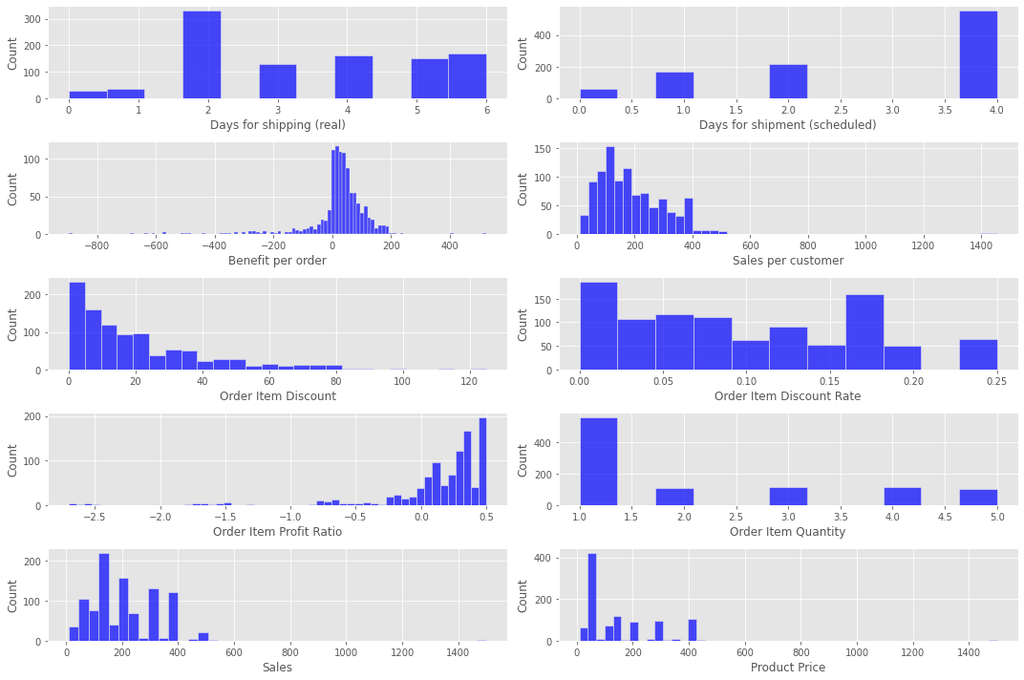

```python
# Variáveis numéricas.

# Amostra dos dados.
df_sample = df1.sample(1000, random_state = 42)

# Especificando as variáveis.
features = nums

# Plotagem.
for col in range(0, len(features)):
    plt.subplot(5, 2, col + 1)
    sns.histplot(x = df_sample[features[col]],
                 color = 'b', alpha = 0.7)
    plt.xlabel(features[col])
    plt.tight_layout()
```

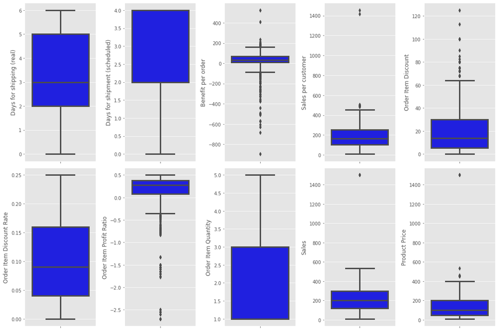

```python
# Variáveis numéricas.

# Especificando as variáveis.
features = nums

# Plotagem.
for col in range(0, len(features)):
    plt.subplot(2, 5, col + 1)
    sns.boxplot(y = df_sample[features[col]],
                color = 'b',
                orient = 'v')
    plt.tight_layout()
```

- Alguns pedidos estão gerando prejuízo para a empresa (valores negativos na **`Benefit per order`**).
- Algumas variáveis possuem uma grande quantidade de *outliers*.

#### 2.3.2 Variáveis Categóricas

```python
# Informações das variáveis.
df1[cats].describe().T
```

|  | count | unique | top | freq |
| --- | --- | --- | --- | --- |
| Type | 180519 | 4 | DEBIT | 69295 |
| Delivery Status | 180519 | 4 | Late delivery | 98977 |
| Late_delivery_risk | 180519 | 2 | 1 | 98977 |
| Customer Segment | 180519 | 3 | Consumer | 93504 |
| Order Status | 180519 | 9 | COMPLETE | 59491 |
| Product Status | 180519 | 1 | 0 | 180519 |
| Shipping Mode | 180519 | 4 | Standard Class | 107752 |

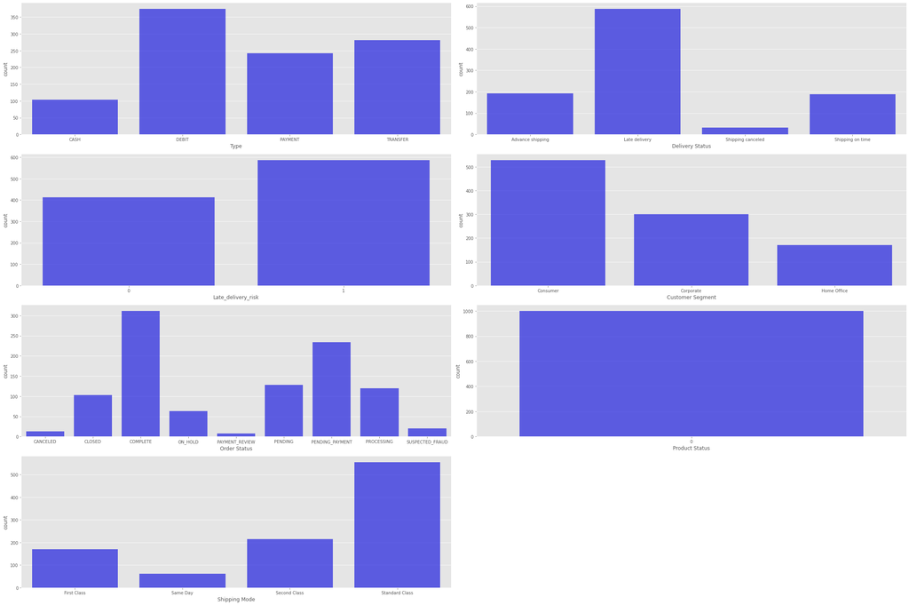

```python
# Variáveis categóricas.

# Redefinindo a área de plotagem.
plt.figure(figsize = (30, 20))

# Especificando as variáveis.
features = cats

# Plotagem.
for col in range(0, len(features)):
    plt.subplot(4, 2, col + 1)
    sns.countplot(x = df_sample[features[col]],
                  color = 'b', alpha = 0.7)
    plt.tight_layout()
```

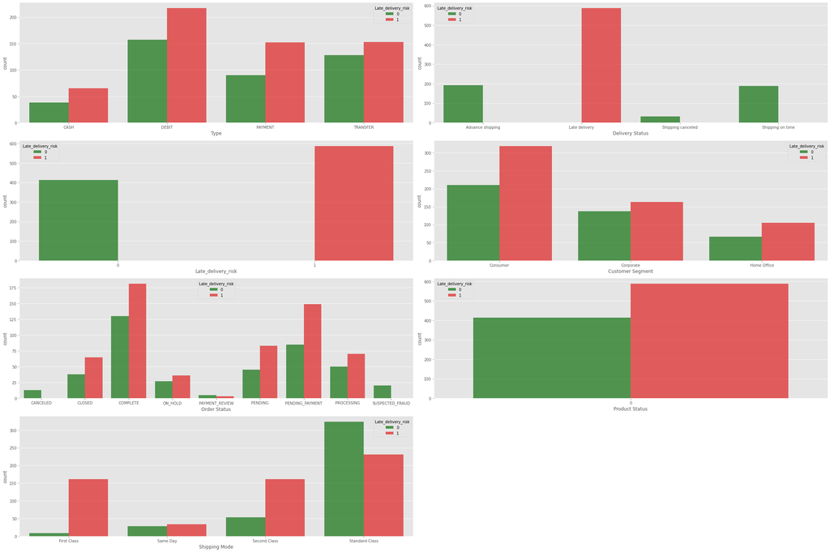

```python
# Variáveis categóricas em relação a variável resposta.

# Redefinindo a área de plotagem.
plt.figure(figsize = (30, 20))

# Especificando as variáveis.
features = cats

# Plotagem.
for col in range(0, len(features)):
    plt.subplot(4, 2, col + 1)
    sns.countplot(data = df_sample,
                  x = features[col],
                  hue = 'Late_delivery_risk',
                  palette = ['g', 'r'],
                  alpha = .7)
    plt.tight_layout()
```

#### 2.3.3 Variáveis Referentes aos Produtos

```python
# Informações das variáveis.
df1[prod].describe().T
```

|  | count | unique | top | freq |
| --- | --- | --- | --- | --- |
| Category Name | 180519 | 50 | Cleats | 24551 |
| Product Name | 180519 | 118 | Perfect Fitness Perfect Rip Deck | 24515 |

```python
# Top 5 itens mais frequentes de cada variável.
for col in prod:
    print(f'''Top 5 Itens Mais Frequentes da Variável {col}:\n''')
    print(df1[col].value_counts().nlargest(5))
    print()
```

```
Top 5 Itens Mais Frequentes da Variável Category Name:

Cleats                  24551
Men's Footwear          22246
Women's Apparel         21035
Indoor/Outdoor Games    19298
Fishing                 17325
Name: Category Name, dtype: int64

Top 5 Itens Mais Frequentes da Variável Product Name:

Perfect Fitness Perfect Rip Deck             24515
Nike Men's CJ Elite 2 TD Football Cleat      22246
Nike Men's Dri-FIT Victory Golf Polo         21035
O'Brien Men's Neoprene Life Vest             19298
Field & Stream Sportsman 16 Gun Fire Safe    17325
Name: Product Name, dtype: int64
```

#### 2.3.4 Variáveis Geográficas

```python
# Informações das variáveis.
df1[geo].describe().T
```

|  | count | unique | top | freq |
| --- | --- | --- | --- | --- |
| Market | 180519 | 5 | LATAM | 51594 |
| Order City | 180519 | 3597 | Santo Domingo | 2211 |
| Order Country | 180519 | 164 | Estados Unidos | 24840 |
| Order Region | 180519 | 23 | Central America | 28341 |
| Order State | 180519 | 1089 | Inglaterra | 6722 |

```python
# Top 5 itens mais frequentes de cada variável.
for col in geo:
    print(f'''Top 5 Itens Mais Frequentes da Variável {col}:\n''')
    print(df1[col].value_counts().nlargest(5))
    print()
```

```
Top 5 Itens Mais Frequentes da Variável Market:

LATAM           51594
Europe          50252
Pacific Asia    41260
USCA            25799
Africa          11614
Name: Market, dtype: int64

Top 5 Itens Mais Frequentes da Variável Order City:

Santo Domingo    2211
New York City    2202
Los Angeles      1845
Tegucigalpa      1783
Managua          1682
Name: Order City, dtype: int64

Top 5 Itens Mais Frequentes da Variável Order Country:

Estados Unidos    24840
Francia           13222
MÃÂ©xico         13172
Alemania           9564
Australia          8497
Name: Order Country, dtype: int64

Top 5 Itens Mais Frequentes da Variável Order Region:

Central America    28341
Western Europe     27109
South America      14935
Oceania            10148
Northern Europe     9792
Name: Order Region, dtype: int64

Top 5 Itens Mais Frequentes da Variável Order State:

Inglaterra                     6722
California                     4966
Isla de Francia                4580
Renania del Norte-Westfalia    3303
San Salvador                   3055
Name: Order State, dtype: int64
```

#### 2.3.5 Variável Temporal

```python
# Data dos pedidos.
print('Data início: {}'.format(df1['order date (DateOrders)'].min()))
print('Data final: {}'.format(df1['order date (DateOrders)'].max()))
```

```
Data início: 1/1/2015 0:00
Data final: 9/9/2017 9:50
```

#### 2.3.6 Variáveis de Identificação

```python
# Registros únicos de cada variável.
for col in idf:
    print(f'''Registros únicos da Variável {col}:''')
    print(len(df1[col].unique()))
    print()
```

```
Registros únicos da Variável Category Id:
51

Registros únicos da Variável Customer Id:
20652

Registros únicos da Variável Order Id:
65752

Registros únicos da Variável Order Item Id:
180519

Registros únicos da Variável Product Card Id:
118
```

#### 2.3.7 Perguntas de Negócio

Agora que entendemos o que as variáveis representam, vamos criar algumas perguntas de negócio.

- **P1.** Qual a categoria de produtos possui o maior número de pedidos que deram prejuízo?
- **P2.** Qual a região registrou o maior faturamento?
- **P3.** Qual a categoria de produtos registrou o maior faturamento?
- **P4.** Qual o dia da semana e mês que registraram o maior faturamento?
- **P5.** Quais os produtos que registraram a maior taxa de lucro?
- **P6.** Qual o método de pagamento mais utilizado em pedidos suspeitos de fraude?
- **P7.** Qual a região e a categoria de produtos que possuem o maior número de pedidos suspeitos de fraude?
- **P8.** Qual o método de envio responsável pelo maior número de pedidos atrasados em cada região?

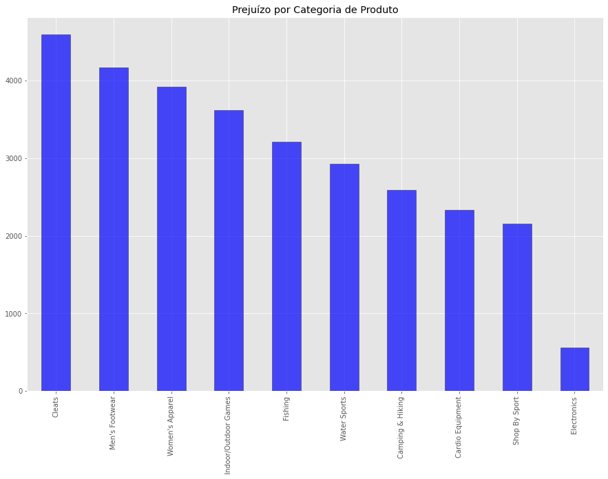

```python
# Pergunta 1.

# Pedidos que deram prejuízo.
aux1 = df1[(df1['Benefit per order'] < 0)]

# Prejuízo por categoria de produtos.
aux1['Category Name'].value_counts().nlargest(10).plot.bar(title = 'Prejuízo por Categoria de Produto',
                                                           color = 'b',
                                                           alpha = .7,
                                                           ec = 'k');
```

```python
# Prejuízo total.
print('Prejuízo Total:', aux1['Benefit per order'].sum())
```

```
Prejuízo Total: -3883547.345768667
```

Pergunta 1:

- **P1.** Qual a categoria de produtos possui o maior número de pedidos que deram prejuízo?
  - Chuteiras, calçados masculinos e vestuário feminino são as principais categorias envolvendo pedidos que deram prejuízo.
  - As perdas totais são de aproximadamente 3,9 milhões de dólares.

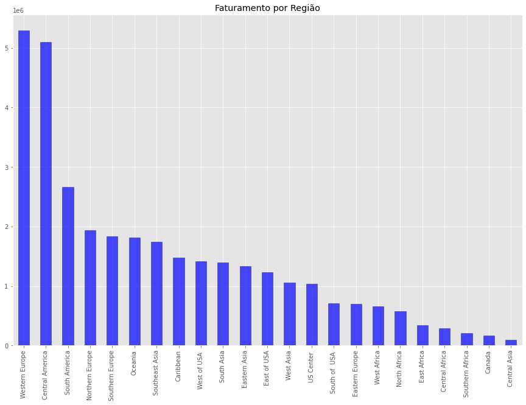

```python
# Pergunta 2.

# Agrupando os dados por região.
aux2 = df1.groupby('Order Region')

# Faturamento por região.
aux2['Sales per customer'].sum().sort_values(ascending = False).plot.bar(title = 'Faturamento por Região',
                                                                         color = 'b',
                                                                         alpha = .7,
                                                                         ec = 'k',
                                                                         xlabel = '');
```

Pergunta 2:

- **P2.** Qual a região registrou o maior faturamento?
  - A Europa Ocidental e a América Central foram as regiões que mais faturaram.

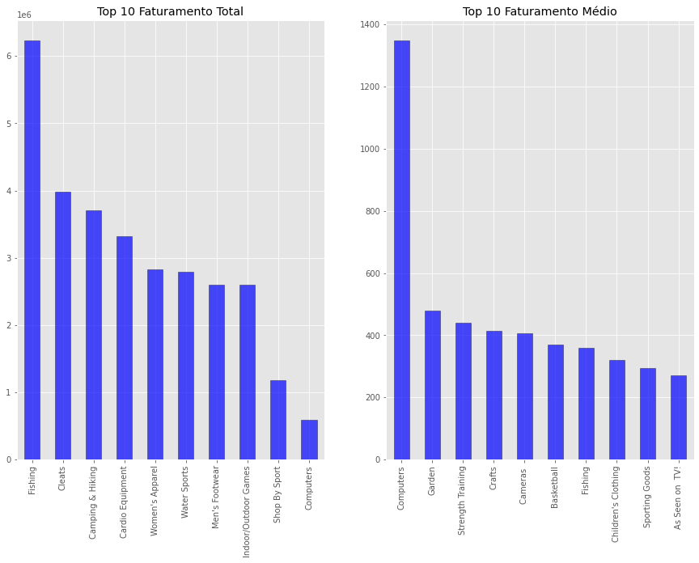

```python
# Pergunta 3.

# Área de plotagem.
fig, (axis1, axis2) = plt.subplots(1, 2)

# Agrupando os dados por categoria.
aux3 = df1.groupby('Category Name')

# Faturamento por categoria.
p1 = aux3['Sales per customer'].sum().sort_values(ascending = False).nlargest(10).plot.bar(title = 'Top 10 Faturamento Total',
                                                                              color = 'b',
                                                                              alpha = .7,
                                                                              ec = 'k',
                                                                              xlabel = '',
                                                                              ax = axis1);
# Faturamento médio por categoria.
p2 = aux3['Sales per customer'].mean().sort_values(ascending = False).nlargest(10).plot.bar(title = 'Top 10 Faturamento Médio',
                                                                               color = 'b',
                                                                               alpha = .7,
                                                                               ec = 'k',
                                                                               xlabel = '',
                                                                               ax = axis2);
```

Pergunta 3:

- **P3.** Qual a categoria de produtos registrou o maior faturamento?
  - A categoria *Fishing*, ou seja, produtos de pesca, registrou o maior faturamento total.
  - A categoria *Computers* registrou o maior faturamento médio.

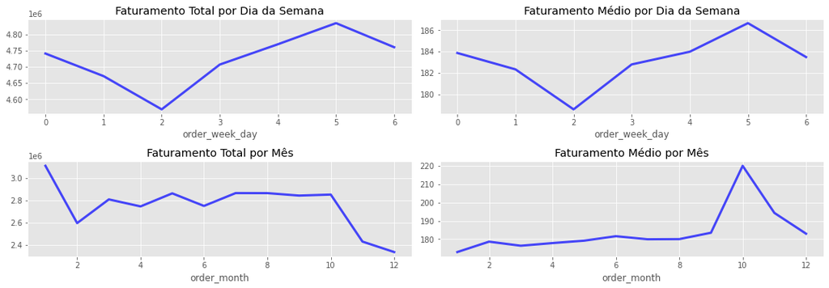

```python
# Pergunta 4.

# Novas variáveis.
df1['order_month'] = pd.DatetimeIndex(df1['order date (DateOrders)']).month
df1['order_week_day'] = pd.DatetimeIndex(df1['order date (DateOrders)']).weekday

# Agrupando os dados.
aux4 = df1.groupby('order_week_day')
aux4_1 = df1.groupby('order_month')

# Faturamento total por dia da semana.
plt.subplot(4, 2, 1)
aux4['Sales per customer'].sum().plot(title = 'Faturamento Total por Dia da Semana',
                                      color = 'b',
                                      alpha = .7)

# Faturamento médio por dia da semana.
plt.subplot(4, 2, 2)
aux4['Sales per customer'].mean().plot(title = 'Faturamento Médio por Dia da Semana',
                                       color = 'b',
                                       alpha = .7)

# Faturamento total por mês.
plt.subplot(4, 2, 3)
aux4_1['Sales per customer'].sum().plot(title = 'Faturamento Total por Mês',
                                        color = 'b',
                                        alpha = .7)

# Faturamento médio por mês.
plt.subplot(4, 2, 4)
aux4_1['Sales per customer'].mean().plot(title = 'Faturamento Médio por Mês',
                                         color = 'b',
                                         alpha = .7)
plt.tight_layout()
```

Pergunta 4:

- **P4.** Qual o dia da semana e mês que registraram o maior faturamento?
  - Sábado (5) é o dia da semana responsável pelo maior faturamento total e médio.
  - Janeiro é o mês que registrou o maior faturamento total, e outubro, o maior faturamento médio.

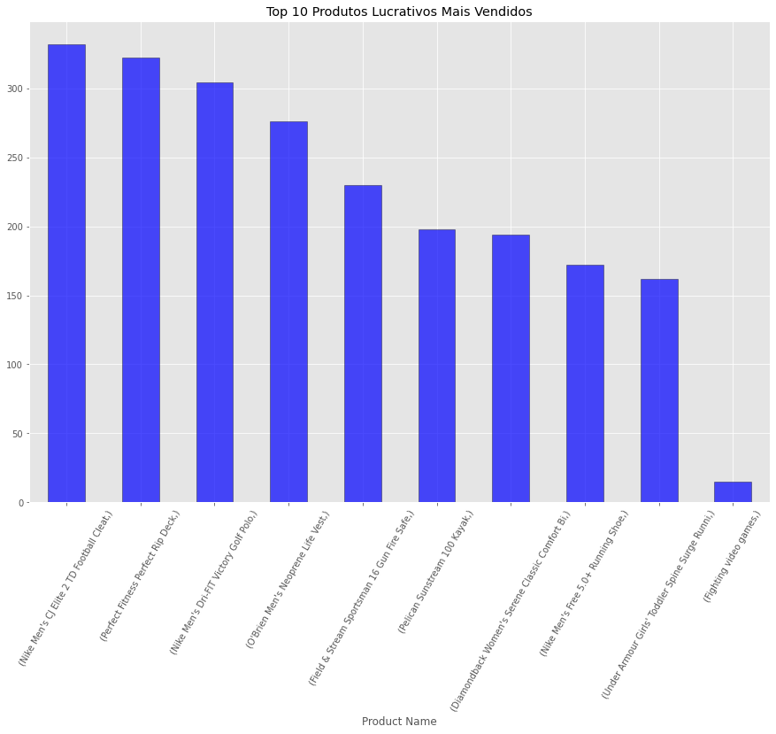

```python
# Pergunta 5.

# Produtos com a maior taxa de lucro.
aux5 = df1[(df1['Order Item Profit Ratio'] == 0.50)]

# Produtos lucrativos mais vendidos.
aux5[['Product Name']].value_counts(ascending = False).nlargest(10).plot.bar(title = 'Top 10 Produtos Lucrativos Mais Vendidos',
                                                                             color = 'b',
                                                                             alpha = .7,
                                                                             ec = 'k')
plt.xticks(rotation = 60);
```

```python
# Quantidade de produtos com taxa de lucro de 50%.
len(aux5['Product Name'].unique())
```

```
96
```

Pergunta 5:

- **P5.** Quais os produtos que registraram a maior taxa de lucro?
  - 96 produtos registraram taxa de lucratividade de 50% em pelo menos 1 pedido.
  - *Nike Men's CJ Elite 2 TD Football Cleat* foi o produto mais vendido entre os que possuem a maior taxa de lucro.

```python
# Pergunta 6.

# Pagamentos suspeitos de fraude.
aux6 = df1[(df1['Order Status'] == 'SUSPECTED_FRAUD')]

# Contagem de registros.
aux6['Type'].value_counts()
```

```
TRANSFER    4062
CASH           0
DEBIT          0
PAYMENT        0
Name: Type, dtype: int64
```

Pergunta 6:

- **P6.** Qual o método de pagamento mais utilizado em pedidos suspeitos de fraude?
  - Todos os pedidos suspeitos de fraude utilizaram a transferência bancária como método de pagamento.

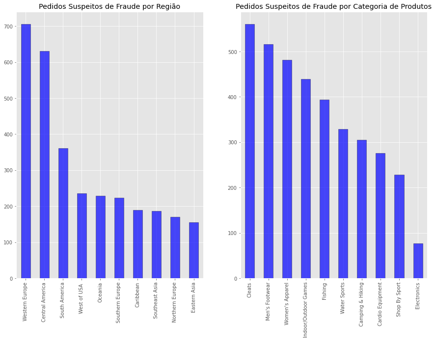

```python
# Pergunta 7.

# Área de plotagem.
fig, (axis1, axis2) = plt.subplots(1, 2)

# Pedidos suspeitos de fraude por região.
aux6['Order Region'].value_counts().nlargest(10).plot.bar(title = 'Pedidos Suspeitos de Fraude por Região',
                                                          color = 'b',
                                                          alpha = .7,
                                                          ec = 'k',
                                                          ax = axis1);

# Pedidos suspeitos de fraude por categoria de produtos.
aux6['Category Name'].value_counts().nlargest(10).plot.bar(title = 'Pedidos Suspeitos de Fraude por Categoria de Produtos',
                                                           color = 'b',
                                                           alpha = .7,
                                                           ec = 'k',
                                                           ax = axis2);
```

Pergunta 7:

- **P7.** Qual a região e a categoria de produtos que possuem o maior número de pedidos suspeitos de fraude?
  - A Europa Ocidental e a América Central foram as regiões que registraram os maiores números de pedidos suspeitos de fraude.
  - Em relação as categorias, *Cleats*, é o item que registrou o maior número de pedidos suspeitos de fraude.

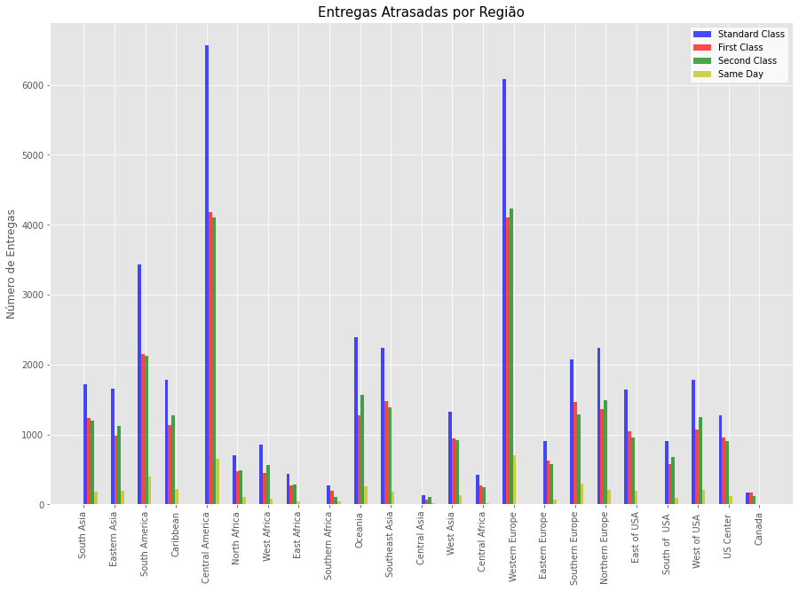

```python
# Pergunta 8.

# Entregas atrasadas por método de envio e região.
aux7 = df1[(df1['Delivery Status'] == 'Late delivery') & (df1['Shipping Mode'] == 'Standard Class')]['Order Region']
aux8 = df1[(df1['Delivery Status'] == 'Late delivery') & (df1['Shipping Mode'] == 'First Class')]['Order Region']
aux9 = df1[(df1['Delivery Status'] == 'Late delivery') & (df1['Shipping Mode'] == 'Second Class')]['Order Region']
aux10 = df1[(df1['Delivery Status'] == 'Late delivery') & (df1['Shipping Mode'] == 'Same Day')]['Order Region']

# Plotagem.
plt.hist([aux7, aux8, aux9, aux10],
         bins = 50,
         density = False,
         alpha = 0.7,
         rwidth = 1.0,
         color = ['b', 'r', 'g', 'y'])

# Labels.
plt.title('Entregas Atrasadas por Região', size = 15)
plt.ylabel('Número de Entregas')
plt.legend(['Standard Class',
            'First Class',
            'Second Class',
            'Same Day'], loc = 'upper right', facecolor = 'white')
plt.xticks(rotation = 90);
```

Pergunta 8:

- **P8.** Qual o método de envio responsável pelo maior número de pedidos atrasados em cada região?
  - Para todas as regiões, o maior número de entregas atrasadas ocorreu pelo método *Standard Class*, porém, esse é o único método em que o número de entregas não atrasadas é maior do que o número de entregas que atrasaram, ou seja, ainda é o método mais eficiente.
  - Em termos percentuais, *First Class* é o método com o pior desempenho nas entregas dos pedidos.

## 3. Engenharia de Atributos

### 3.1 Extração de Variáveis (Feature Extraction)

Vamos agrupar as categorias de produtos em uma nova variável de acordo com as classes abaixo:

- *Men's Clothing*.
- *Women's Clothing*.
- *Children*.
- *Sports Materials*.
- *Electronic Devices*.
- *Lazer*.
- *Health and Beauty*.
- *Pets and Gardens*.
- *Others*.

```python
# Cópia do dataframe.
df2 = df1.copy()
```

```python
# Criando a nova variável.
df2['Category Prod'] = df2['Category Name'].str.replace(' ', '')
```

```python
# Criando as novas classes.

# Men's Clothing.
df2["Category Prod"] = df2["Category Prod"].replace(["Men'sFootwear",
                                                     "Men'sClothing"], "Men's Clothing")

# Women's Clothing.
df2["Category Prod"].replace(["Women'sApparel",
                              "Women'sClothing",
                              "Accessories"], "Women's Clothing", inplace = True)

# Children.
df2["Category Prod"].replace(["Children'sClothing",
                              "Children",
                              "Girls'Apparel",
                              "Toys",
                              "Baby"], "Children", inplace = True)

# Sports Materials.
df2["Category Prod"].replace(["Cleats",
                              "Fishing",
                              "WaterSports",
                              "GolfBalls",
                              "GolfGloves",
                              "Baseball&Softball",
                              "Hockey",
                              "GolfShoes",
                              "GolfApparel",
                              "Boxing&MMA",
                              "Kids'GolfClubs",
                              "SportingGoods",
                              "Lacrosse",
                              "Tennis&Racquet",
                              "Fitness",
                              "Men'sGolfClubs",
                              "Women'sGolf",
                              "Clubs",
                              "Soccer",
                              "StrengthTraining",
                              "Basketball",
                              "GolfBags&Carts",
                              "ShopBySport",
                              "Camping&Hiking",
                              "CardioEquipment",
                              "SportsWomen'sClothing",
                              "Sports",
                              "Hunting&Shooting",
                              "FitnessWomen's Clothing",
                              "Women'sGolfClubs",
                              "FitnessAccessories"], "Sports Materials", inplace = True)

# Electronic Devices.
df2["Category Prod"].replace(["Electronics",
                              "VideoGames",
                              "Cameras",
                              "Computers",
                              "ConsumerElectronics"], "Electronic Devices", inplace = True)

# Lazer.
df2["Category Prod"].replace(["Music",
                              "DVDs",
                              "Books",
                              "CDs",
                              "AsSeenonTV!",
                              "Entertainment",
                              "Indoor/OutdoorGames"], "Lazer", inplace = True)

# Health and Beauty.
df2["Category Prod"].replace(["HealthandBeauty"],
                              "Health and Beauty", inplace = True)

# Pets and Gardens.
df2["Category Prod"].replace(["PetSupplies",
                              "Crafts",
                              "Garden"], "Pets and Gardens", inplace = True)

# Others.
df2["Category Prod"].replace(["Trade-In"], "Others", inplace = True)
```

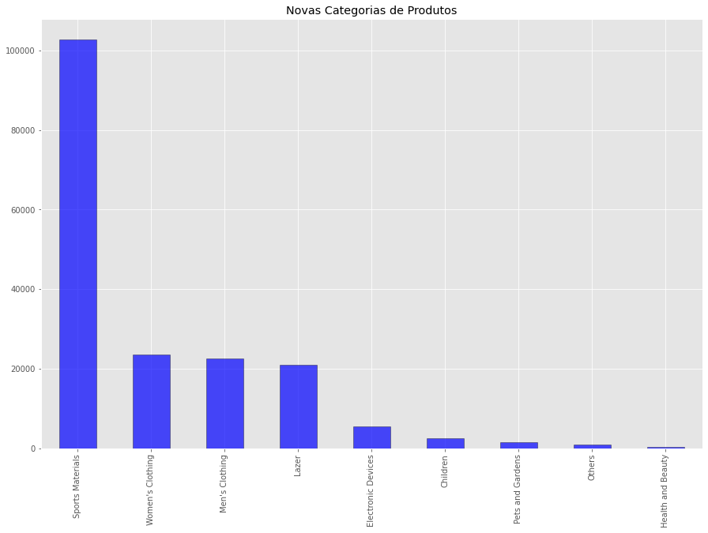

```python
# Novas categorias de produtos.
df2['Category Prod'].value_counts(ascending = False).plot.bar(title = 'Novas Categorias de Produtos',
                                                              color = 'b',
                                                              alpha = .7,
                                                              ec = 'k');
```

### 3.2 Seleção de Variáveis (Feature Selection)

#### 3.2.1 Variáveis com Vazamento de Informações

Essas variáveis de certa forma já sabem o resultado da variável resposta. Por esse motivo, elas serão desconsideradas da análise preditiva.

- **`Days for shipping (real)`**
- **`Delivery Status`**
- **`Order Status`**

```python
# Variáveis com vazamento de informações
del1 = ['Days for shipping (real)',
        'Delivery Status',
        'Order Status']
```

#### 3.2.2 Variáveis com Informações Semelhantes

Essas variáveis contêm informações semelhantes ou irrelevantes para a modelagem, sendo assim, também serão removidas.

```python
# Variáveis com informações semelhantes ou irrelevantes.
del2 = ['Customer Id',
        'Customer Segment',
        'Order Id',
        'Order Item Discount Rate',
        'Order Item Id',
        'Order Item Profit Ratio',
        'Sales',
        'Product Price',
        'Product Status']

# Variáveis com informações representadas pela "Category Prod".
del3 = ['Category Id',
        'Category Name',
        'Product Card Id',
        'Product Name']

# Variável temporal representada pela "order_month" e "order_week_day".
del4 = ['order date (DateOrders)']

# Variáveis geográficas representadas pela "Market" e "Order Region".
del5 = ['Order City',
        'Order Country',
        'Order State']
```

#### 3.2.3 Análise de Correlação

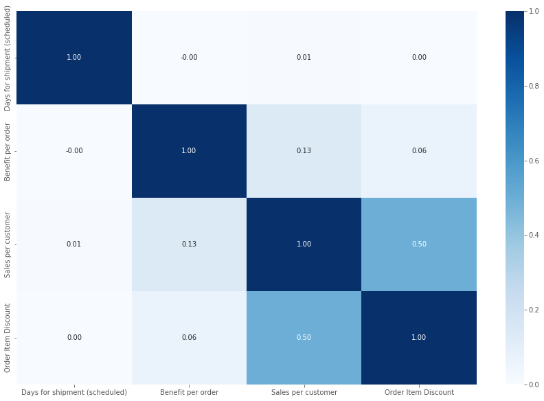

```python
# Matriz de correlação.
corr_df = df2[['Days for shipment (scheduled)',
               'Benefit per order',
               'Sales per customer',
               'Order Item Discount']].corr()

# Plotagem.
sns.heatmap(corr_df,
            cmap = 'Blues',
            annot = True,
            fmt = '.2f');
```

```python
# Seleção de variáveis.

# Lista de variáveis para remoção.
vars_del = del1 + del2 + del3 + del4 + del5

# Variáveis selecionadas.
vars_sel = [item for item in df2.columns if item not in vars_del]

# Novo dataframe.
df3 = df2[vars_sel]
```

```python
# Visualizando o dataframe.
df3.head()
```

|  | Type | Days for shipment (scheduled) | Benefit per order | Sales per customer | Late_delivery_risk | Market | Order Item Discount | Order Item Quantity | Order Region | Shipping Mode | order_month | order_week_day | Category Prod |
| --- | --- | --- | --- | --- | --- | --- | --- | --- | --- | --- | --- | --- | --- |
| 0 | DEBIT | 4 | 91.250000 | 314.640015 | 0 | Pacific Asia | 13.110000 | 1 | Southeast Asia | Standard Class | 1 | 2 | Sports Materials |
| 1 | TRANSFER | 4 | -249.089996 | 311.359985 | 1 | Pacific Asia | 16.389999 | 1 | South Asia | Standard Class | 1 | 5 | Sports Materials |
| 2 | CASH | 4 | -247.779999 | 309.720001 | 0 | Pacific Asia | 18.030001 | 1 | South Asia | Standard Class | 1 | 5 | Sports Materials |
| 3 | DEBIT | 4 | 22.860001 | 304.809998 | 0 | Pacific Asia | 22.940001 | 1 | Oceania | Standard Class | 1 | 5 | Sports Materials |
| 4 | PAYMENT | 4 | 134.210007 | 298.250000 | 0 | Pacific Asia | 29.500000 | 1 | Oceania | Standard Class | 1 | 5 | Sports Materials |

#### 3.2.4 Divisão dos Dados em Treino e Teste

Criaremos dois conjuntos, conforme especificado abaixo:

- Conjuntos de treino e teste contendo as variáveis originais, removendo apenas informações duplicadas.
- Conjuntos de treino e teste contendo apenas as variáveis selecionadas e criadas durante o projeto.

```python
# Conjuntos com todas as variáveis.

# Separando os dados.
X = df2.loc[:, df2.columns != 'Late_delivery_risk',]
y = df2['Late_delivery_risk']

# Removendo as variáveis com informações duplicadas.
X = X.drop(['Category Name',
            'Order City',
            'Order Country',
            'order date (DateOrders)',
            'Order State',
            'Product Name',
            'Category Prod'], axis = 1)

# Removendo as variáveis com vazamento de informação.
X = X.drop(['Days for shipping (real)',
            'Delivery Status',
            'Order Status'], axis = 1)

# Divisão treino/teste.
X_train_all, X_test_all, y_train_all, y_test_all = train_test_split(X, y, test_size = 0.3, random_state = 42)

# Dimensão dos conjuntos.
print('Conjunto de Treino: {}'.format(X_train_all.shape))
print('Conjunto de Teste: {}'.format(X_test_all.shape))
```

```
Conjunto de Treino: (126363, 22)
Conjunto de Teste: (54156, 22)
```

```python
# Conjuntos com variáveis selecionadas.

# Separando os dados.
X = df3.loc[:, df3.columns != 'Late_delivery_risk',]
y = df3['Late_delivery_risk']

# Divisão treino/teste.
X_train, X_test, y_train, y_test = train_test_split(X, y, test_size = 0.3, random_state = 42)

# Dimensão dos conjuntos.
print('Conjunto de Treino: {}'.format(X_train.shape))
print('Conjunto de Teste: {}'.format(X_test.shape))
```

```
Conjunto de Treino: (126363, 12)
Conjunto de Teste: (54156, 12)
```

## 4. Pré-Processamento dos Dados

Nessa etapa, iremos preparar os dados para a etapa da modelagem preditiva.

Em meu blog, há um artigo onde explico com mais detalhes algumas das principais técnicas utilizadas nessa etapa, basta acessar [este link](https://medium.com/@rafaelfelippe_/pr%C3%A9-processamento-de-dados-com-python-d2c607d134f).

### 4.1 Codificação de Variáveis

Aplicaremos a codificação *One Hot Enconding* as variáveis categóricas.

```python
# Conjuntos com todas as variáveis.

# Variáveis categóricas.
object_vars_all = ['Type',
                   'Customer Segment',
                   'Market',
                   'Order Region',
                   'Shipping Mode']

# Aplicando a transformação.
train_OHE_all = pd.get_dummies(X_train_all[object_vars_all])
test_OHE_all = pd.get_dummies(X_test_all[object_vars_all])

# Concatenando as variáveis criadas aos conjuntos.
X_train_all = pd.concat([X_train_all, train_OHE_all], axis = 1)
X_test_all = pd.concat([X_test_all, test_OHE_all], axis = 1)

# Excluindo as variáveis transformadas.
X_train_all = X_train_all.drop(['Type',
                                'Customer Segment',
                                'Market',
                                'Order Region',
                                'Shipping Mode'], axis = 1)

X_test_all = X_test_all.drop(['Type',
                              'Customer Segment',
                              'Market',
                              'Order Region',
                              'Shipping Mode'], axis = 1)

# Visualizando o dataframe.
X_train_all.head()
```

|  | Days for shipment (scheduled) | Benefit per order | Sales per customer | Category Id | Customer Id | Order Id | Order Item Discount | Order Item Discount Rate | Order Item Id | Order Item Profit Ratio | Order Item Quantity | Sales | Product Card Id | Product Price | Product Status | order_month | order_week_day | Type_CASH | Type_DEBIT | Type_PAYMENT | Type_TRANSFER | Customer Segment_Consumer | Customer Segment_Corporate | Customer Segment_Home Office | Market_Africa | Market_Europe | Market_LATAM | Market_Pacific Asia | Market_USCA | … |
| --- | --- | --- | --- | --- | --- | --- | --- | --- | --- | --- | --- | --- | --- | --- | --- | --- | --- | --- | --- | --- | --- | --- | --- | --- | --- | --- | --- | --- | --- | --- |
| 99963 | 2 | -190.570007 | 122.949997 | 46 | 5276 | 38385 | 26.990000 | 0.18 | 95797 | -1.55 | 3 | 149.940002 | 1014 | 49.980000 | 0 | 7 | 3 | 0 | 0 | 0 | 1 | 1 | 0 | 0 | 0 | 0 | 0 | 0 | 1 | … |
| 63538 | 4 | -9.960000 | 199.250000 | 70 | 15980 | 72427 | 11.600000 | 0.06 | 175742 | -0.05 | 1 | 210.850006 | 1357 | 210.850006 | 0 | 11 | 3 | 1 | 0 | 0 | 0 | 0 | 0 | 1 | 0 | 0 | 0 | 1 | 0 | … |
| 6661 | 4 | 52.910000 | 151.169998 | 17 | 3382 | 29091 | 28.799999 | 0.16 | 72792 | 0.35 | 3 | 179.970001 | 365 | 59.990002 | 0 | 2 | 0 | 0 | 0 | 1 | 0 | 0 | 0 | 1 | 0 | 0 | 0 | 1 | 0 | … |
| 93913 | 4 | 3.900000 | 97.489998 | 18 | 2655 | 28583 | 32.500000 | 0.25 | 71534 | 0.04 | 1 | 129.990005 | 403 | 129.990005 | 0 | 2 | 0 | 0 | 1 | 0 | 0 | 1 | 0 | 0 | 0 | 0 | 0 | 1 | 0 | … |
| 90626 | 4 | -22.150000 | 103.989998 | 18 | 1356 | 67502 | 26.000000 | 0.20 | 168750 | -0.21 | 1 | 129.990005 | 403 | 129.990005 | 0 | 9 | 1 | 0 | 0 | 1 | 0 | 0 | 1 | 0 | 0 | 1 | 0 | 0 | 0 | … |

```python
# Conjuntos com variáveis selecionadas.

# Variáveis categóricas.
object_vars = ['Type',
               'Market',
               'Order Region',
               'Shipping Mode',
               'Category Prod']

# Aplicando a transformação.
train_OHE = pd.get_dummies(X_train[object_vars])
test_OHE = pd.get_dummies(X_test[object_vars])

# Concatenando as variáveis criadas aos conjuntos.
X_train = pd.concat([X_train, train_OHE], axis = 1)
X_test = pd.concat([X_test, test_OHE], axis = 1)

# Excluindo as variáveis transformadas.
X_train = X_train.drop(['Type',
                        'Market',
                        'Order Region',
                        'Shipping Mode',
                        'Category Prod'], axis = 1)

X_test = X_test.drop(['Type',
                      'Market',
                      'Order Region',
                      'Shipping Mode',
                      'Category Prod'], axis = 1)

# Visualizando o dataframe.
X_train.head()
```

|  | Days for shipment (scheduled) | Benefit per order | Sales per customer | Order Item Discount | Order Item Quantity | order_month | order_week_day | Type_CASH | Type_DEBIT | Type_PAYMENT | Type_TRANSFER | Market_Africa | Market_Europe | Market_LATAM | Market_Pacific Asia | Market_USCA | Order Region_Canada | Order Region_Caribbean | Order Region_Central Africa | Order Region_Central America | Order Region_Central Asia | Order Region_East Africa | Order Region_East of USA | Order Region_Eastern Asia | Order Region_Eastern Europe | Order Region_North Africa | Order Region_Northern Europe | Order Region_Oceania | Order Region_South America | … |
| --- | --- | --- | --- | --- | --- | --- | --- | --- | --- | --- | --- | --- | --- | --- | --- | --- | --- | --- | --- | --- | --- | --- | --- | --- | --- | --- | --- | --- | --- | --- |
| 99963 | 2 | -190.570007 | 122.949997 | 26.990000 | 3 | 7 | 3 | 0 | 0 | 0 | 1 | 0 | 0 | 0 | 0 | 1 | 0 | 0 | 0 | 0 | 0 | 0 | 0 | 0 | 0 | 0 | 0 | 0 | 0 | … |
| 63538 | 4 | -9.960000 | 199.250000 | 11.600000 | 1 | 11 | 3 | 1 | 0 | 0 | 0 | 0 | 0 | 0 | 1 | 0 | 0 | 0 | 0 | 0 | 0 | 0 | 0 | 1 | 0 | 0 | 0 | 0 | 0 | … |
| 6661 | 4 | 52.910000 | 151.169998 | 28.799999 | 3 | 2 | 0 | 0 | 0 | 1 | 0 | 0 | 0 | 0 | 1 | 0 | 0 | 0 | 0 | 0 | 0 | 0 | 0 | 0 | 0 | 0 | 0 | 0 | 0 | … |
| 93913 | 4 | 3.900000 | 97.489998 | 32.500000 | 1 | 2 | 0 | 0 | 1 | 0 | 0 | 0 | 0 | 0 | 1 | 0 | 0 | 0 | 0 | 0 | 0 | 0 | 0 | 1 | 0 | 0 | 0 | 0 | 0 | … |
| 90626 | 4 | -22.150000 | 103.989998 | 26.000000 | 1 | 9 | 1 | 0 | 0 | 1 | 0 | 0 | 1 | 0 | 0 | 0 | 0 | 0 | 0 | 0 | 0 | 0 | 0 | 0 | 0 | 0 | 1 | 0 | 0 | … |

### 4.2 Padronização dos Dados

A padronização é o processo de redimensionamento das variáveis para que elas tenham as propriedades de uma distribuição normal, ou seja, com a média igual a 0 e desvio padrão igual a 1. Uma forma de padronizar os dados é através do método *StandardScaler*, que utilizaremos a seguir.

```python
# Instanciando o objeto.
scaler = StandardScaler()
```

```python
# Padronizando as variáveis.

# Conjuntos com todas as variáveis.
X_train_all = scaler.fit_transform(X_train_all)
X_test_all = scaler.transform(X_test_all)

# Conjuntos com as variáveis selecionadas.
X_train = scaler.fit_transform(X_train)
X_test = scaler.transform(X_test)
```

Devemos normalizar/padronizar os conjuntos de forma individual para que não haja "vazamento" de informações.

## 5. Modelagem Preditiva

### 5.1 Seleção do Melhor Algoritmo

Criaremos uma função para treinar diversos algoritmos de classificação. Essa função utiliza apenas os dados de treino, aqui, nosso objetivo é selecionar o melhor algoritmo, e avaliar se há diferenças significativas em relação ao desempenho dos modelos com os diferentes conjuntos de dados.

```python
# Criando a função.
def classifiersTraining(features, tTarget, printMeans = True, scoring = 'f1'):

    # Número de folds.
    num_folds = 5

    # Listas para armazenar informações.
    models = []
    results = []
    names = []
    means = pd.DataFrame(columns = ['mean'])

    # Modelos testados.
    models.append(('AdaBoost', AdaBoostClassifier()))
    models.append(('ETC', ExtraTreesClassifier()))
    models.append(('GB', GradientBoostingClassifier()))
    models.append(('LR', LogisticRegression()))
    models.append(('RF', RandomForestClassifier()))
    models.append(('XGBoost' , xgb.XGBClassifier(use_label_encoder = False, eval_metric = 'mlogloss')))

    # Avaliação dos modelos.
    for name, model in models:
        skf = StratifiedKFold(n_splits = num_folds)
        cv_results = cross_val_score(model, features, tTarget, cv = skf, scoring = scoring)
        results.append(cv_results)
        names.append(name)

        # Adicionando os resultados gerados pelo modelo ao dataframe.
        means = means.append(pd.DataFrame(data = [[cv_results.mean()]],
                                          columns = ['mean'],
                                          index   = [name]))

        # Imprime a mensagem contendo os resultados obtidos.
        if printMeans:
            msg = '%s: %f' % (name, cv_results.mean())
            print(msg)

    # Salva os resultados em um dataframe.
    results = pd.DataFrame(np.transpose(results), columns = names)

    # Retorna o dataframe com os resultados.
    return (results, means)
```

```python
# Desempenho com todas as variáveis.
results = classifiersTraining(features = X_train_all, tTarget = y_train_all)
```

```
AdaBoost: 0.668033
ETC: 0.741556
GB: 0.665644
LR: 0.662303
RF: 0.713082
XGBoost: 0.695874
```

```python
# Desempenho com as variáveis selecionadas.
results = classifiersTraining(features = X_train, tTarget = y_train)
```

```
AdaBoost: 0.665057
ETC: 0.691262
GB: 0.663232
LR: 0.662280
RF: 0.691049
XGBoost: 0.671849
```

Conseguimos um desempenho bastante parecido em ambos conjuntos de dados, ou seja, as variáveis selecionadas são bastantes representativas.

### 5.2 Criação do Modelo Preditivo

Seguiremos a modelagem com o algoritmo que melhor performou com os dados de treino.

```python
# Instanciando o modelo.
model = ExtraTreesClassifier(random_state = 42)
```

Criaremos uma nova função com objetivo de treinar o modelo instanciado e verificar suas principais métricas de desempenho.

```python
# Criando a função.
def classifiermodel(model, X_train, y_train):

    # Treinamento do modelo.
    model = model.fit(X_train, y_train)

    # Previsões obtidas na validação cruzada.
    y_train_pred = cross_val_predict(model, X_train, y_train, cv = 5)

    # Métricas de desempenho.
    accuracy = accuracy_score(y_train, y_train_pred)
    precision = precision_score(y_train, y_train_pred)
    recall = recall_score(y_train, y_train_pred)
    f1 = f1_score(y_train, y_train_pred)
    conf = confusion_matrix(y_train, y_train_pred, labels = [1, 0])

    print('Modelo:', model)
    print('Acurácia do modelo:', (accuracy) * 100, '%')
    print('Precision do Modelo:', (precision) * 100, '%')
    print('Recall do modelo:', (recall) * 100, '%')
    print('F1 score:', (f1) * 100, '%')
    print('Matriz de Confusão:\n',  (conf))
```

```python
# Aplicando a função.
classifiermodel(model, X_train, y_train)
```

```
Modelo: ExtraTreesClassifier(random_state=42)
Acurácia do modelo: 67.40976393406298 %
Precision do Modelo: 71.91200824922663 %
Recall do modelo: 66.48370695632077 %
F1 score: 69.09140035125114 %
Matriz de Confusão:
 [[46028 23204]
 [17978 39153]]
```

Acima temos as métricas do modelo com os dados de treino:

- **Acurácia**: indica uma performance geral do modelo, dentre todas as classificações, quantas o modelo classificou corretamente.
  - 85.181 (46.028 + 39.153) / 126.363 (total) = 67,4%.
- **Precision**: dentre todas as previsões realizadas para uma classe, quantas o modelo acertou.
  - 46.028 / 64.006 (46.028 + 17.978) = 71,9%
- **Recall**: dentre todos os registros reais de uma classe, quantos foram classificados corretamente
  - 46.028 / 69.232 (46.028 + 23.204) = 66,4%
- **F1-score**: média harmônica entre *precision* e *recall*.

Também podemos analisar a matriz de confusão:

- 46.028 registros da classe positiva foram classificados corretamente.
- 23.204 registros da classe positiva foram classificados erroneamente para a classe negativa.
- 17.978 registros da classe negativa foram classificados erroneamente para a classe positiva.
- 39.153 registros da classe negativa foram classificados corretamente.

Agora, apresentaremos os dados de teste ao modelo!

```python
# Previsões com dados de teste.
y_pred = model.predict(X_test)
```

```python
# Avaliação do modelo.
print(classification_report(y_test, y_pred))
```

```
              precision    recall  f1-score   support

           0       0.63      0.68      0.66     24411
           1       0.72      0.67      0.69     29745

    accuracy                           0.68     54156
   macro avg       0.67      0.68      0.67     54156
weighted avg       0.68      0.68      0.68     54156
```

Conseguimos um *recall* de aproximadamente 70% para as classes, o que é considerado um desempenho satisfatório para um primeiro ciclo do projeto.

```python
# Matriz de confusão
conf_test = confusion_matrix(y_test, y_pred, labels = [1, 0])
print('Matriz de Confusão:\n',  (conf_test))
```

```
Matriz de Confusão:
 [[19854  9891]
 [ 7699 16712]]
```

Interpretação:

- 19.854 registros da classe positiva foram classificados corretamente.
- 9.891 registrso da classe positiva foram classificados erroneamente para a classe negativa.
- 7.699 registros da classe negativa foram classificados erroneamente para a classe positiva.
- 16.712 registros da classe negativa foram classificados corretamente.

Com isso, podemos seguir para a segmentação dos clientes.

## 6. Segmentação de Clientes

Vamos dar início a resolução do segundo objetivo desse projeto: a segmentação dos clientes da GO Market.

Embora exista diversos meios para atingir esse objetivo, aqui, vamos utilizar a análise RFM.

A análise RFM é uma estratégia para estimar o valor de um cliente, com base em três variáveis:

- **Recency (recência)**: quanto mais recente tiver sido a última compra de um cliente, mais pontos ele recebe aqui.
- **Frequency (frequência)**: quanto maior for o número de compras de um cliente, maior também será sua pontuação neste quesito.
- **Monetary (monetário)**: quanto maior for o gasto do cliente em compras, maior a pontuação.

Para aplicação dessa análise utilizaremos o dataset *df2*, pois vamos precisar de algumas variáveis que desconsideramos durante a análise exploratória.

Vamos iniciar criando uma nova variável, que receberá a data do dia seguinte do último pedido registrado no conjunto de dados.

```python
# Data posterior do último pedido.
last_order_data = datetime.datetime(2018, 2, 1)
```

Também iremos converter o tipo da variável das datas.

```python
# Convertendo a variável.
df2['order date (DateOrders)'] = pd.to_datetime(df2['order date (DateOrders)'])
```

O código abaixo basicamente já nos dará as 3 variáveis da análise RFM.

Iremos agrupar os dados utilizando a variável **`Customer Id`** que representa a identificação única de cada cliente.

Para calcular a recência, ou seja, a data da última compra de cada cliente, iremos utilizar a variável que criamos **`last_order_data`**, e subtrair a data do último pedido gerado pelo cliente, assim, teremos a quantidade de dias desde o último pedido do cliente.

Além disso, observe que estamos pegando o número total de encomendas e o faturamento total para cada cliente, isso representa a frequência e o valor monetário respectivamente.

```python
# Análise RFM.
df_seg = df2.groupby('Customer Id').agg({'order date (DateOrders)': lambda x: (last_order_data - x.max()).days,
                                         'Order Id': lambda x: len(x), 'Sales per customer': lambda x: x.sum()})
```

Agora, basta converter a coluna das datas para números inteiros.

```python
# Convertendo a variável.
df_seg['order date (DateOrders)'] = df_seg['order date (DateOrders)'].astype(int)
```

```python
# Renomeando as colunas.
df_seg.rename(columns = {'order date (DateOrders)': 'R',
                         'Order Id': 'F',
                         'Sales per customer': 'M'}, inplace = True)
```

```python
# Visualizando o dataframe.
df_seg.head()
```

| Customer Id | R | F | M |
| --- | --- | --- | --- |
| 1 | 792 | 1 | 472.450012 |
| 2 | 136 | 10 | 1618.660042 |
| 3 | 229 | 18 | 3189.200037 |
| 4 | 380 | 14 | 1480.709993 |
| 5 | 457 | 7 | 1101.919998 |

-**R (Recência)**: indica quantos dias se passaram desde o último pedido do cliente.

-**F (Frequência)**: indica a quantidade de pedidos feitos pelo cliente.

-**M (Monetário)**: indica o valor gasto pelo cliente.

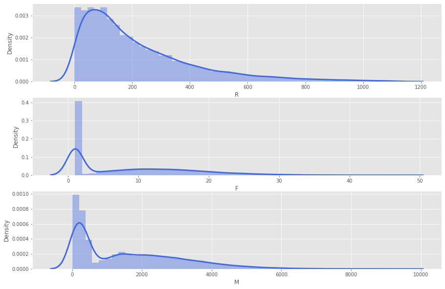

```python
# Densidade das variáveis RFM.

plt.subplot(3, 1, 1)
sns.distplot(df_seg['R'], color = 'royalblue')

plt.subplot(3, 1, 2)
sns.distplot(df_seg['F'], color = 'royalblue')

plt.subplot(3, 1, 3)
sns.distplot(df_seg['M'], color = 'royalblue');
```

Baseado nas plotagens acima, vemos que:

- Temos uma grande quantidade de clientes que estão a mais de 200 dias sem realizarem um pedido.
- A maioria dos clientes realizaram um número baixo de pedidos.
- O gasto total dos clientes não costuma ultrapassar o valor de 2000 dólares.

Com os valores RFM definidos podemos iniciar a segmentação. Vamos dividir o dataframe com os valores RFM em 4 partes.

```python
# Divisão do dataframe.
quantiles = df_seg.quantile(q = [0.25, 0.5, 0.75, 1])
quantiles
```

|  | R | F | M |
| --- | --- | --- | --- |
| 0.25 | 75.0 | 1.0 | 254.940002 |
| 0.50 | 159.0 | 7.0 | 1294.504997 |
| 0.75 | 307.0 | 15.0 | 2621.140007 |
| 1.00 | 1125.0 | 47.0 | 9436.610088 |

Acima temos os valores máximos da RFM para cada quartil.

Porém não faz sentido entregar essa divisão para a empresa, pois o R deve ser baixo, indicando que o cliente está ativo na empresa, e o F e M devem ser altos, pois indicam a frequência e o valor total da compra.

Sendo assim, iremos definir duas funções que irão realizar essa filtragem.

```python
# Convertendo o dataframe.
quantiles = quantiles.to_dict()
```

Com a função *R_Score*, iremos classificar os valores de R. Os valores serão classificados em grupos de 1 a 4, onde o grupo 1 receberá os menores valores de R, ou seja, os melhores valores, até o grupo 4, que receberá os valores mais altos de R.

```python
# Função para classificar o "R".
def R_Score(a, b, c):
    if a <= c[b][0.25]:
        return 1
    elif a <= c[b][0.50]:
        return 2
    elif a <= c[b][0.75]:
        return 3
    else:
        return 4
```

Para a função *FM_Score*, a lógica é a mesma da *R_Score*.

Porém aqui, desejamos obter os maiores valores, sendo assim, esses valores serão classificados como 1, e os menores valores como 4.

```python
# Função para classificar o "F" e o "M".
def FM_Score(x, y, z):
    if x <= z[y][0.25]:
        return 4
    elif x <= z[y][0.50]:
        return 3
    elif x <= z[y][0.75]:
        return 2
    else:
        return 1
```

Com as duas funções definidas, podemos realizar a classificação.

```python
# Classificando valores de "R".
df_seg['R_Score'] = df_seg['R'].apply(R_Score, args = ('R', quantiles))

# Classificando valores de "F".
df_seg['F_Score'] = df_seg['F'].apply(FM_Score, args = ('F', quantiles))

# Classificando valores de "M".
df_seg['M_Score'] = df_seg['M'].apply(FM_Score, args = ('M', quantiles))
```

```python
# Visualizando o dataframe.
df_seg.head()
```

| Customer Id | R | F | M | R_Score | F_Score | M_Score |
| --- | --- | --- | --- | --- | --- | --- |
| 1 | 792 | 1 | 472.450012 | 4 | 4 | 3 |
| 2 | 136 | 10 | 1618.660042 | 2 | 2 | 2 |
| 3 | 229 | 18 | 3189.200037 | 3 | 1 | 1 |
| 4 | 380 | 14 | 1480.709993 | 4 | 2 | 2 |
| 5 | 457 | 7 | 1101.919998 | 4 | 3 | 3 |

A classificação funcionou como esperado!

Agora, vamos concatenar esses valores em uma nova variável.

```python
# Nova variável.
df_seg['RFM_Score'] = df_seg.R_Score.astype(str) + df_seg.F_Score.astype(str) + df_seg.M_Score.astype(str)
df_seg.head()
```

| Customer Id | R | F | M | R_Score | F_Score | M_Score | RFM_Score |
| --- | --- | --- | --- | --- | --- | --- | --- |
| 1 | 792 | 1 | 472.450012 | 4 | 4 | 3 | 443 |
| 2 | 136 | 10 | 1618.660042 | 2 | 2 | 2 | 222 |
| 3 | 229 | 18 | 3189.200037 | 3 | 1 | 1 | 311 |
| 4 | 380 | 14 | 1480.709993 | 4 | 2 | 2 | 422 |
| 5 | 457 | 7 | 1101.919998 | 4 | 3 | 3 | 433 |

Veremos quantos diferentes grupos foram criados.

```python
# Contagem dos grupos.
count = df_seg['RFM_Score'].unique()
print(count)
len(count)
```

```
['443' '222' '311' '422' '433' '421' '211' '221' '323' '434' '212' '411'
 '332' '312' '412' '321' '322' '423' '333' '233' '444' '432' '223' '334'
 '232' '343' '234' '243' '344' '244' '242' '143' '144' '142']
```

```
34
```

Temos 34 diferentes grupos de clientes diferentes.

Para facilitar, vamos agrupar esses grupos somando os valores RFM.

```python
# Nova variável.
df_seg['RFM_Total_Score'] = df_seg[['R_Score', 'F_Score', 'M_Score']].sum(axis = 1)
```

```python
# Grupos de clientes.
df_seg['RFM_Total_Score'].unique()
```

```
array([11,  6,  5,  8, 10,  7,  4,  9, 12], dtype=int64)
```

Criaremos uma função para nomear os grupos de acordo com a pontuação de cada um.

```python
# Criando a função.
def RFM_Total_Score(df):

    if (df['RFM_Total_Score'] >= 11):
        return 'Especial'

    elif (df['RFM_Total_Score'] == 10):
        return 'Fiel'

    elif (df['RFM_Total_Score'] == 9):
        return 'Frequente'

    elif (df['RFM_Total_Score'] == 8):
         return 'Promissor'

    elif (df['RFM_Total_Score'] == 7):
        return 'Comprador'

    elif (df['RFM_Total_Score'] == 6):
        return 'Em Alerta'

    elif (df['RFM_Total_Score'] == 5):
        return 'Em Risco'

    else:
        return 'Inativo'
```

```python
# Nomeando os grupos de clientes.
df_seg['Segmentation'] = df_seg.apply(RFM_Total_Score, axis = 1)
```

```python
# Visualizando o dataframe.
df_seg.head()
```

| Customer Id | R | F | M | R_Score | F_Score | M_Score | RFM_Score | RFM_Total_Score | Segmentation |
| --- | --- | --- | --- | --- | --- | --- | --- | --- | --- |
| 1 | 792 | 1 | 472.450012 | 4 | 4 | 3 | 443 | 11 | Especial |
| 2 | 136 | 10 | 1618.660042 | 2 | 2 | 2 | 222 | 6 | Em Alerta |
| 3 | 229 | 18 | 3189.200037 | 3 | 1 | 1 | 311 | 5 | Em Risco |
| 4 | 380 | 14 | 1480.709993 | 4 | 2 | 2 | 422 | 8 | Promissor |
| 5 | 457 | 7 | 1101.919998 | 4 | 3 | 3 | 433 | 10 | Fiel |

Vamos visualizar a porcentagem de clientes em cada grupo.

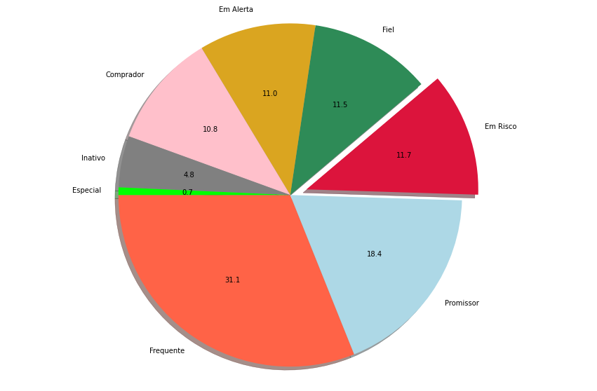

```python
# Segmentação de clientes.
df_seg['Segmentation'].value_counts().plot.pie(startangle = 180,
                                               explode = (0, 0, 0.1, 0, 0, 0, 0, 0),
                                               autopct = '%.1f',
                                               shadow = True,
                                               ylabel = '',
                                               colors = ['tomato',
                                                         'lightblue',
                                                         'crimson',
                                                         'seagreen',
                                                         'goldenrod',
                                                         'pink',
                                                         'gray',
                                                         'lime',
                                                         'violet'])
plt.axis('equal');
```

Se necessário também podemos filtrar o dataframe utilizando a coluna **`RFM_Score`**.

Como vimos, ela possui uma maior diversificação dos segmentos. Por exemplo, podemos filtrar clientes do grupo 411.

```python
# Clientes do grupo 411.
df_seg[(df_seg['RFM_Score'] == '411')].sort_values('M', ascending = False).head(10)
```

| Customer Id | R | F | M | R_Score | F_Score | M_Score | RFM_Score | RFM_Total_Score | Segmentation |
| --- | --- | --- | --- | --- | --- | --- | --- | --- | --- |
| 664 | 335 | 39 | 7549.040138 | 4 | 1 | 1 | 411 | 6 | Em Alerta |
| 4781 | 502 | 31 | 7258.970126 | 4 | 1 | 1 | 411 | 6 | Em Alerta |
| 9271 | 344 | 35 | 7012.680107 | 4 | 1 | 1 | 411 | 6 | Em Alerta |
| 1492 | 355 | 38 | 6934.600078 | 4 | 1 | 1 | 411 | 6 | Em Alerta |
| 773 | 326 | 34 | 6800.940094 | 4 | 1 | 1 | 411 | 6 | Em Alerta |
| 1695 | 326 | 33 | 6786.770100 | 4 | 1 | 1 | 411 | 6 | Em Alerta |
| 11065 | 309 | 41 | 6733.980038 | 4 | 1 | 1 | 411 | 6 | Em Alerta |
| 468 | 340 | 32 | 6569.600109 | 4 | 1 | 1 | 411 | 6 | Em Alerta |
| 7417 | 339 | 36 | 6471.100122 | 4 | 1 | 1 | 411 | 6 | Em Alerta |
| 5648 | 350 | 41 | 6457.320080 | 4 | 1 | 1 | 411 | 6 | Em Alerta |

Aqui, temos clientes que costumavam fazer pedidos em grandes quantidades e com muita frequência, mas que agora, não realizam pedidos há muito tempo.

Isso pode significar que esses clientes estão migrando para outras empresas. Talvez seja interessante conversar com o departamento de Marketing para elaborar promoções especiais a fim de recuperar esse grupo de clientes.

```python
# Clientes dos grupos 144 ou 143.
df_seg[(df_seg['RFM_Score'] == '144')|(df_seg['RFM_Score'] == '143')].sort_values('M', ascending = False).head(10)
```

| Customer Id | R | F | M | R_Score | F_Score | M_Score | RFM_Score | RFM_Total_Score | Segmentation |
| --- | --- | --- | --- | --- | --- | --- | --- | --- | --- |
| 18053 | 39 | 1 | 1275.0 | 1 | 4 | 3 | 143 | 8 | Promissor |
| 18089 | 38 | 1 | 1275.0 | 1 | 4 | 3 | 143 | 8 | Promissor |
| 18071 | 39 | 1 | 1275.0 | 1 | 4 | 3 | 143 | 8 | Promissor |
| 18125 | 38 | 1 | 1275.0 | 1 | 4 | 3 | 143 | 8 | Promissor |
| 18035 | 39 | 1 | 1275.0 | 1 | 4 | 3 | 143 | 8 | Promissor |
| 18107 | 38 | 1 | 1275.0 | 1 | 4 | 3 | 143 | 8 | Promissor |
| 18070 | 39 | 1 | 1260.0 | 1 | 4 | 3 | 143 | 8 | Promissor |
| 18052 | 39 | 1 | 1260.0 | 1 | 4 | 3 | 143 | 8 | Promissor |
| 18124 | 38 | 1 | 1260.0 | 1 | 4 | 3 | 143 | 8 | Promissor |
| 18088 | 38 | 1 | 1260.0 | 1 | 4 | 3 | 143 | 8 | Promissor |

Os clientes desses grupos possuem boas chances de se tornarem os melhores clientes.

Aqui, o departamento de marketing deve aplicar esforços para fidelizar esses grupos.

## 7. Conclusões Finais

Nesse projeto, tínhamos dois objetivos: auxiliar a GO Market a identificar pedidos que possuem risco de atraso e realizar a segmentação de seus clientes.

Para alcançar o primeiro objetivo, identificamos a necessidade da criação de um modelo preditivo. Durante as etapas do projeto, foi identificado uma grande quantidade de variáveis irrelevantes e com informações duplicadas no conjunto de dados disponibilizado pela empresa. Sendo assim, realizamos um tratamento nesses dados, onde conseguimos filtrar as variáveis mais representativas.

Já na fase da modelagem, após testar diversos algoritmos de classificação, o algoritmo escolhido foi o *ExtraTreesClassifier*. Para um primeiro ciclo do projeto, conseguimos um desempenho razoável, conforme as métricas abaixo:

- *Accuracy:* 0.68
- *Precision:* 0.72
- *Recall:* 0.67
- *F1-score:* 0.69

Um *recall* de 0.67 para a classe positiva, significa que implementando o nosso modelo, a GO Market conseguiria identificar 67% dos pedidos que atrasaram, e assim, tomar as devidas precauções para evitar esses atrasos. Ainda vale ressaltar que para um próximo ciclo desse projeto, poderíamos testar outros métodos de pré-processamento dos dados, visando aumentar a performance do modelo.

Agora, a GO Market já pode direcionar ações para evitar os atrasos dos pedidos e fidelizar ainda mais seus clientes!